# Examples of emmeans

Author

Clay Ford

Published

March 24, 2023

## Intro

In this document I show how to use {emmeans} after fitting a model to make various comparisons.

## Fit a model

```r
library(lme4)
# read in data;
# see get_emergence_data.R
d <- readRDS(file = "emergence.rds")

# fit logistic regression model with experiment as random effect
m <- glmer(emergence ~ day * treatment + (1|experiment),
           data = d, family = binomial(link = "probit"),
           weights = total)
```

The interaction certainly seems significant.

```r
car::Anova(m)
```

```
Analysis of Deviance Table (Type II Wald chisquare tests)

Response: emergence
                Chisq Df Pr(>Chisq)
day           1596.97  1  < 2.2e-16 ***
treatment     1628.81  3  < 2.2e-16 ***
day:treatment  724.07  3  < 2.2e-16 ***
---
Signif. codes:  0 '***' 0.001 '**' 0.01 '*' 0.05 '.' 0.1 ' ' 1
```

We can visualize the model using {ggeffects}.

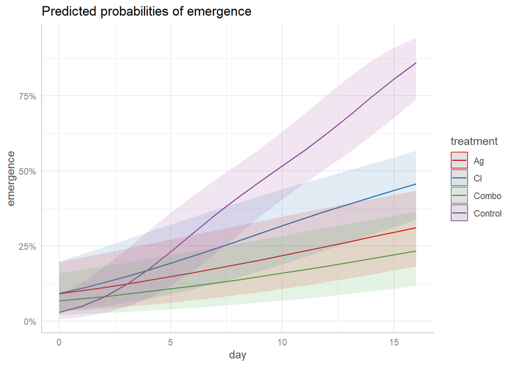

```r
library(ggeffects)
ggeffect(m, terms = c("day[0:16]", "treatment"),
         bias_correction = TRUE) |> plot()
```

## Use {emmeans} to investigate model

Some examples of using emmeans to quantify relationships we see in the plot.

### 1. Compare Cl to Combo at day 16

Specify `pairwise ~ treatment | day` to make all pairwise comparisons, but them set `at = list(day = 16, treatment = c("Cl", "Combo"))` to restrict comparisons to Cl and Combo at Day 16. We set `regrid = "response"` to make comparison in terms of probabilities instead of probits.

```r
library(emmeans)
emmeans(m, specs = pairwise ~ treatment | day,
        at = list(day = 16, treatment = c("Cl", "Combo")),
        regrid = "response")
```

```
$emmeans
day = 16:
 treatment  prob    SE  df asymp.LCL asymp.UCL
 Cl        0.415 0.108 Inf   0.20321     0.628
 Combo     0.117 0.055 Inf   0.00939     0.225

Confidence level used: 0.95

$contrasts
day = 16:
 contrast   estimate     SE  df z.ratio p.value
 Cl - Combo    0.298 0.0563 Inf   5.296  <.0001
```

The output says that Cl is 0.415 at Day 16 and that Combo is 0.117 at Day 16. The difference between them (under contrasts) is about 0.298. That difference appears to reliably positive (ie, “significant”). We can get confidence intervals by piping the result into `confint()`.

```r
emmeans(m, specs = pairwise ~ treatment | day,
        at = list(day = 16, treatment = c("Cl", "Combo")),
        regrid = "response") |>
  confint()
```

```
$emmeans
day = 16:
 treatment  prob    SE  df asymp.LCL asymp.UCL
 Cl        0.415 0.108 Inf   0.20321     0.628
 Combo     0.117 0.055 Inf   0.00939     0.225

Confidence level used: 0.95

$contrasts
day = 16:
 contrast   estimate     SE  df asymp.LCL asymp.UCL
 Cl - Combo    0.298 0.0563 Inf     0.188     0.409

Confidence level used: 0.95
```

The 95% CI is reported as [0.19,0.41]. The difference in Cl - Combo appears to be at least 0.19, perhaps as high as 0.41. All data in the CI range is plausible. The estimated difference of 0.298 is but one value. Instead of stating with certainty the difference is 0.298 we might say the difference appears to be in the range of [0.19, 0.41].

### 2. Compare Day 10 to Day 16 for all treatments

Is there a difference in emergence between Day 10 and Day 16 within each treatment? The syntax `revpairwise ~ day | treatment` says compare days within treatments in “reverse” order, which in this case means day 16 - day 10. By setting `at = list(day = c(10, 16))` we make predictions at just day 10 and 16. This returns predicted probabilities at days 10 and 16 as well as the difference in probabilities between those days. Each difference is also tested against the null of no difference between days.

```r
emmeans(m, specs = revpairwise ~ day | treatment,
        at = list(day = c(10, 16)),
        regrid = "response")
```

```
$emmeans
treatment = Ag:
 day   prob     SE  df asymp.LCL asymp.UCL
  10 0.1048 0.0501 Inf   0.00658     0.203
  16 0.1925 0.0762 Inf   0.04317     0.342

treatment = Cl:
 day   prob     SE  df asymp.LCL asymp.UCL
  10 0.1998 0.0771 Inf   0.04859     0.351
  16 0.4154 0.1080 Inf   0.20321     0.628

treatment = Combo:
 day   prob     SE  df asymp.LCL asymp.UCL
  10 0.0643 0.0347 Inf  -0.00382     0.132
  16 0.1172 0.0550 Inf   0.00939     0.225

treatment = Control:
 day   prob     SE  df asymp.LCL asymp.UCL
  10 0.5326 0.1100 Inf   0.31768     0.747
  16 0.9475 0.0299 Inf   0.88890     1.006

Confidence level used: 0.95

$contrasts
treatment = Ag:
 contrast      estimate     SE  df z.ratio p.value
 day16 - day10   0.0876 0.0271 Inf   3.239  0.0012

treatment = Cl:
 contrast      estimate     SE  df z.ratio p.value
 day16 - day10   0.2157 0.0327 Inf   6.589  <.0001

treatment = Combo:
 contrast      estimate     SE  df z.ratio p.value
 day16 - day10   0.0529 0.0211 Inf   2.509  0.0121

treatment = Control:
 contrast      estimate     SE  df z.ratio p.value
 day16 - day10   0.4149 0.0801 Inf   5.180  <.0001
```

Again we can pipe into `confint()` for confidence intervals.

```r
emmeans(m, specs = revpairwise ~ day | treatment,
        at = list(day = c(10, 16)),
        regrid = "response") |>
  confint()
```

```
$emmeans
treatment = Ag:
 day   prob     SE  df asymp.LCL asymp.UCL
  10 0.1048 0.0501 Inf   0.00658     0.203
  16 0.1925 0.0762 Inf   0.04317     0.342

treatment = Cl:
 day   prob     SE  df asymp.LCL asymp.UCL
  10 0.1998 0.0771 Inf   0.04859     0.351
  16 0.4154 0.1080 Inf   0.20321     0.628

treatment = Combo:
 day   prob     SE  df asymp.LCL asymp.UCL
  10 0.0643 0.0347 Inf  -0.00382     0.132
  16 0.1172 0.0550 Inf   0.00939     0.225

treatment = Control:
 day   prob     SE  df asymp.LCL asymp.UCL
  10 0.5326 0.1100 Inf   0.31768     0.747
  16 0.9475 0.0299 Inf   0.88890     1.006

Confidence level used: 0.95

$contrasts
treatment = Ag:
 contrast      estimate     SE  df asymp.LCL asymp.UCL
 day16 - day10   0.0876 0.0271 Inf    0.0346    0.1407

treatment = Cl:
 contrast      estimate     SE  df asymp.LCL asymp.UCL
 day16 - day10   0.2157 0.0327 Inf    0.1515    0.2798

treatment = Combo:
 contrast      estimate     SE  df asymp.LCL asymp.UCL
 day16 - day10   0.0529 0.0211 Inf    0.0116    0.0942

treatment = Control:
 contrast      estimate     SE  df asymp.LCL asymp.UCL
 day16 - day10   0.4149 0.0801 Inf    0.2579    0.5719

Confidence level used: 0.95
```

### 3. Contrasts of contrasts

In the previous comparison, Ag and Combo had a difference on 0.0876 and 0.0529, respectively, between days 10 and 16. Are those differences significantly different?

This requires a little extra work. First we use emmeans as before without `revpairwise` and save the result.

```r
emg <- emmeans(m, specs = ~ day | treatment,
        at = list(day = c(10, 16)),
        regrid = "response")
emg
```

```
treatment = Ag:
 day   prob     SE  df asymp.LCL asymp.UCL
  10 0.1048 0.0501 Inf   0.00658     0.203
  16 0.1925 0.0762 Inf   0.04317     0.342

treatment = Cl:
 day   prob     SE  df asymp.LCL asymp.UCL
  10 0.1998 0.0771 Inf   0.04859     0.351
  16 0.4154 0.1080 Inf   0.20321     0.628

treatment = Combo:
 day   prob     SE  df asymp.LCL asymp.UCL
  10 0.0643 0.0347 Inf  -0.00382     0.132
  16 0.1172 0.0550 Inf   0.00939     0.225

treatment = Control:
 day   prob     SE  df asymp.LCL asymp.UCL
  10 0.5326 0.1100 Inf   0.31768     0.747
  16 0.9475 0.0299 Inf   0.88890     1.006

Confidence level used: 0.95
```

Now we use the `pairs()` function to create the first set of contrasts by “day”. This is where the previous example ended

```r
pairs(emg, simple = "day", reverse = TRUE) |> confint()
```

```
treatment = Ag:
 contrast      estimate     SE  df asymp.LCL asymp.UCL
 day16 - day10   0.0876 0.0271 Inf    0.0346    0.1407

treatment = Cl:
 contrast      estimate     SE  df asymp.LCL asymp.UCL
 day16 - day10   0.2157 0.0327 Inf    0.1515    0.2798

treatment = Combo:
 contrast      estimate     SE  df asymp.LCL asymp.UCL
 day16 - day10   0.0529 0.0211 Inf    0.0116    0.0942

treatment = Control:
 contrast      estimate     SE  df asymp.LCL asymp.UCL
 day16 - day10   0.4149 0.0801 Inf    0.2579    0.5719

Confidence level used: 0.95
```

Now we use `pairs()` *again* to compare those contrasts, except this time we set `by = NULL`.

```r
pairs(pairs(emg, simple = "day", reverse = TRUE), by = NULL)
```

```
 contrast                                        estimate     SE  df z.ratio
 (day16 - day10 Ag) - (day16 - day10 Cl)          -0.1280 0.0166 Inf  -7.714
 (day16 - day10 Ag) - (day16 - day10 Combo)        0.0347 0.0138 Inf   2.510
 (day16 - day10 Ag) - (day16 - day10 Control)     -0.3273 0.1060 Inf  -3.096
 (day16 - day10 Cl) - (day16 - day10 Combo)        0.1628 0.0183 Inf   8.888
 (day16 - day10 Cl) - (day16 - day10 Control)     -0.1993 0.1110 Inf  -1.796
 (day16 - day10 Combo) - (day16 - day10 Control)  -0.3620 0.0999 Inf  -3.625
 p.value
  <.0001
  0.0583
  0.0106
  <.0001
  0.2754
  0.0016

P value adjustment: tukey method for comparing a family of 4 estimates
```

In row 2 we see the difference in differences between Day 10 and Day 16 for Ag vs Combo is marginally significant at 0.0583. There is possibly some evidence of difference but we probably shouldn’t rule out the possibility that a different sample could yield different results.